# Project 4

ouR_Markdown

2023-09-25

## Introduction

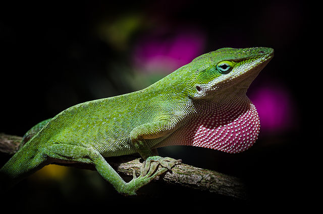

An Anolis lizard

## Methods

To investigate the morphological and allometric variations within the Anolis species, we employed two datasets: one containing morphological measurements and the other containing microhabitat data. These datasets included measurements of species from both Queensland, Australia, and the Caribbean. To facilitate analysis, we combined and logarithmically transformed the provided species data. Subsequently, we created four phylogenetic generalized least squares models using Brownian and Ornstein-Uhlenbeck motion modeling.

Brownian motion modeling assumes that trait values change randomly in both direction and distance over any time interval. This implies that the evolution of traits involves a substantial random component, accounting for the potential for traits to evolve differently in various circumstances (Harmon 2019). In contrast, Ornstein-Uhlenbeck motion modeling suggests that evolution occurs under stabilizing selection, guiding traits towards an optimal state (Harmon 2019).

Following the development of these models, we assessed the goodness of fit for each model using information theory. This analysis helped us determine which model provided the best fit for the variation observed in hind-limb traits.

## Results

```r
anole <- read_csv("anole.dat.csv")
anole.eco <- read_csv("anole.eco.csv")
anole.tree <- read.tree("anole.tre")
```

```r
anole2 <- anole%>%
left_join(anole.eco)%>%
  filter(!Ecomorph%in%c("U","CH"))%>%
  na.omit()

anole.log <- anole2%>%
  mutate_at(c("SVL", "HTotal","PH","ArbPD"),log)
```

```r
### phylogenetic GLS models

#PGLS under BM, no ecomorph
pgls.BM1 <- gls(HTotal ~SVL, correlation = corBrownian(1,phy = anole.tree,form=~Species),data = anole.log, method = "ML")

#PGLS under BM, w ecomorph
pgls.BM2 <- gls(HTotal ~SVL * Ecomorph2, correlation = corBrownian(1,phy = anole.tree,form=~Species),data = anole.log, method = "ML")

#PGLS under OU, no ecomorph
pgls.OU1 <- gls(HTotal ~SVL, correlation = corMartins(0,phy = anole.tree,form=~Species),data = anole.log, method = "ML")

#PGLS under OU, w, ecomorph
pgls.OU2 <- gls(HTotal ~SVL * Ecomorph2, correlation = corMartins(0,phy = anole.tree,form=~Species),data = anole.log, method = "ML")
```

```r
#AIC operations
anole.phylo.aic <- AICc(pgls.BM1,pgls.BM2,pgls.OU1,pgls.OU2)
anole.phylow.aicw <- aicw(anole.phylo.aic$AICc)
```

```r
anole.phylo.aic %>%
  kable(caption = "Table of AICs")
```

Table of AICs

|  | df | AICc |
| --- | --- | --- |
| pgls.BM1 | 3 | -63.66118 |
| pgls.BM2 | 13 | -92.98036 |
| pgls.OU1 | 4 | -57.31864 |
| pgls.OU2 | 14 | -84.89770 |

```r
#add phylo-corrected residuals
anole.log <- anole.log%>%
  mutate(phylo.res=residuals(pgls.BM2))
```

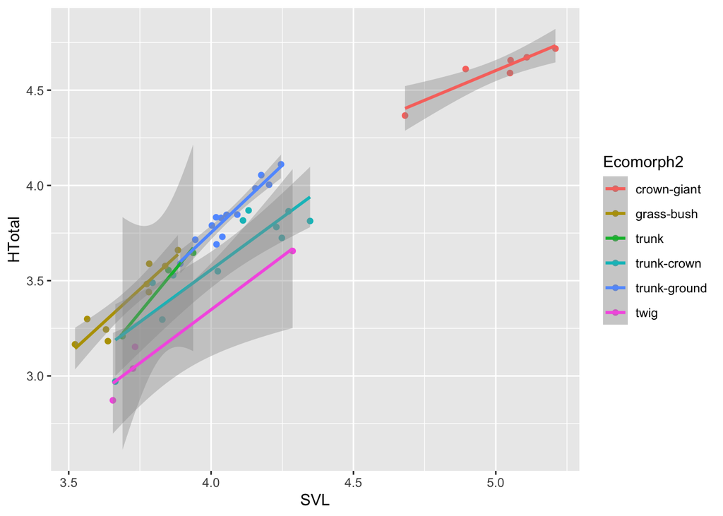

Regression plot of log-transformed HTotal vs SVL

```r
anole.log%>%
  ggplot(aes(SVL,HTotal,col=Ecomorph2))+geom_point()+geom_smooth(method="lm")
```

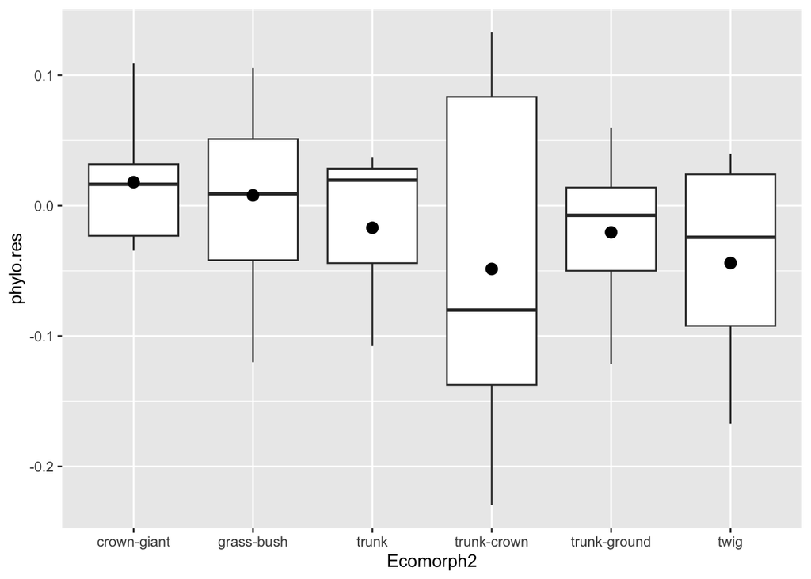

Boxplot of phylogenetically corrected hindlimb residuals versus anole ecomorph

```r
#plot residuals
p.eco.phylo <- anole.log%>%
ggplot(aes(x=Ecomorph2,y=phylo.res)) +geom_boxplot() +stat_summary(fun=mean, geom="point", size=3)

print(p.eco.phylo)
```

Following a thorough evaluation of the suitability of the four phylogenetic models, it was observed that the pgls.BM2 model exhibited the lowest AIC score. This signifies that it demonstrated a superior fit to the data when compared to the other models. Within this particular model, ecomorphology was considered as a contributing factor influencing the relationship between hindlimb and SVL, with its effects explained by the process of evolution through Brownian motion.

## Discussion

By identifying the most suitable model among the four options for describing the *Anolis* data, we find that the relationship between hindlimb and SVL is best characterized by a model incorporating ecomorphology and adhering to Brownian motion. This implies that the evolution of these traits, hindlimb and SVL, follows a random pattern. Moreover, the inclusion of ecomorphology as a factor indicates that this random evolution occurs independently within each lineage, further highlighting the role of stochastic processes in shaping these traits.

## Author Contributions

Michael Bevilacqua: Created the repository, and wrote the code for questions #1, #3-#7  
Audrey Berger: Wrote the information and found correct source for #2 and #8, checked other questions with own code to compare  
Susanne Hahs: Checked, edited, and compared code, as well as edited writing

## References

Hagey, Travis J, Scott Harte, Mathew Vickers, Luke J Harmon, and Lin Schwarzkopf. 2017. “There’s More Than One Way to Climb a Tree: Limb Length and Microhabitat Use in Lizards with Toe Pads.” *PloS One* 12 (9): e0184641.

Harmon, Luke. 2019. “Phylogenetic Comparative Methods: Learning from Trees.”